# Ownership Weight Optimizer

Finding optimal appeal-score weights for FanTeam Monster

04 February 2026

# Overview

This report systematically tests different **appeal-score weight combinations** for the ownership estimation model and identifies which weighting best predicts actual FanTeam Monster contest ownership.

**Approach:**

1. Load historical gameweek data (salaries, odds, stats) + actual ownership
2. For each weight combination, compute appeal scores → exponential concentration → position budgets
3. Compare predicted vs actual ownership (MAE, correlation, top-player accuracy)
4. Report the winning weights and how much improvement is possible

```r
# ============================================================
# SHARED HELPERS
# ============================================================

log_msg <- function(..., level = "INFO") {
  msg <- paste(...)
  message(sprintf("## [%s] [%s] %s", format(Sys.time(), "%H:%M:%S"), level, msg))
}

# ============================================================
# TEAM NORMALISATION — UNIFIED APPROACH
# Mirrors the app's FANTEAM_CLUB_MAPPING + TEAM_NAME_MAPPING
# so that BOTH 3-letter codes AND full names → same canonical form
# ============================================================

# FanTeam 3-letter code → Canonical name (from soccer_fanteam_loader.R)
CLUB_CODE_TO_CANONICAL <- c(
  "ARS" = "Arsenal", "AV" = "Aston Villa", "AVL" = "Aston Villa",
  "BOU" = "Bournemouth", "BRE" = "Brentford", "BHA" = "Brighton",
  "BUR" = "Burnley", "CHE" = "Chelsea", "CRY" = "Crystal Palace",
  "EVE" = "Everton", "FUL" = "Fulham", "IPS" = "Ipswich Town",
  "LEE" = "Leeds United", "LEI" = "Leicester City", "LIV" = "Liverpool",
  "MCI" = "Manchester City", "MUN" = "Manchester United",
  "NEW" = "Newcastle United", "NFO" = "Nottingham Forest",
  "NTG" = "Nottingham Forest", "SOU" = "Southampton",
  "SUN" = "Sunderland", "TOT" = "Tottenham",
  "WHU" = "West Ham", "WOL" = "Wolves",
  # Championship
  "BIR" = "Birmingham City", "BLK" = "Blackburn Rovers",
  "BRC" = "Bristol City", "CAR" = "Cardiff City",
  "COV" = "Coventry City", "DER" = "Derby County",
  "HUL" = "Hull City", "LUT" = "Luton Town",
  "MID" = "Middlesbrough", "MIL" = "Millwall",
  "NOR" = "Norwich City", "PLY" = "Plymouth Argyle",
  "PNE" = "Preston North End", "QPR" = "Queens Park Rangers",
  "SHU" = "Sheffield United", "SHW" = "Sheffield Wednesday",
  "STK" = "Stoke City", "SWA" = "Swansea City",
  "WAT" = "Watford", "WBA" = "West Brom"
)

# Full/variant name → Canonical name (from soccer_config.R TEAM_NAME_MAPPING)
FULL_NAME_TO_CANONICAL <- c(
  "Arsenal" = "Arsenal", "Aston Villa" = "Aston Villa",
  "Bournemouth" = "Bournemouth", "AFC Bournemouth" = "Bournemouth",
  "Brentford" = "Brentford", "Brighton" = "Brighton",
  "Brighton & Hove Albion" = "Brighton", "Brighton and Hove Albion" = "Brighton",
  "Chelsea" = "Chelsea", "Crystal Palace" = "Crystal Palace",
  "Everton" = "Everton", "Fulham" = "Fulham",
  "Ipswich" = "Ipswich Town", "Ipswich Town" = "Ipswich Town",
  "Leicester" = "Leicester City", "Leicester City" = "Leicester City",
  "Liverpool" = "Liverpool",
  "Manchester Utd" = "Manchester United", "Manchester United" = "Manchester United",
  "Man Utd" = "Manchester United", "Man United" = "Manchester United",
  "Newcastle Utd" = "Newcastle United", "Newcastle United" = "Newcastle United",
  "Nott'ham Forest" = "Nottingham Forest", "Nottingham Forest" = "Nottingham Forest",
  "Nottm Forest" = "Nottingham Forest",
  "Southampton" = "Southampton", "Tottenham" = "Tottenham",
  "Tottenham Hotspur" = "Tottenham", "Spurs" = "Tottenham",
  "West Ham" = "West Ham", "West Ham United" = "West Ham",
  "Wolves" = "Wolves", "Wolverhampton Wanderers" = "Wolves",
  "Wolverhampton" = "Wolves",
  "Manchester City" = "Manchester City", "Man City" = "Manchester City",
  # Championship extras
  "Birmingham City" = "Birmingham City", "Birmingham" = "Birmingham City",
  "Blackburn Rovers" = "Blackburn Rovers", "Blackburn" = "Blackburn Rovers",
  "Bristol City" = "Bristol City", "Bristol" = "Bristol City",
  "Burnley" = "Burnley",
  "Cardiff City" = "Cardiff City", "Cardiff" = "Cardiff City",
  "Coventry City" = "Coventry City", "Coventry" = "Coventry City",
  "Derby County" = "Derby County", "Derby" = "Derby County",
  "Hull City" = "Hull City", "Hull" = "Hull City",
  "Leeds United" = "Leeds United", "Leeds" = "Leeds United",
  "Luton Town" = "Luton Town", "Luton" = "Luton Town",
  "Middlesbrough" = "Middlesbrough", "Boro" = "Middlesbrough",
  "Millwall" = "Millwall",
  "Norwich City" = "Norwich City", "Norwich" = "Norwich City",
  "Plymouth Argyle" = "Plymouth Argyle", "Plymouth" = "Plymouth Argyle",
  "Preston North End" = "Preston North End", "Preston" = "Preston North End",
  "Queens Park Rangers" = "Queens Park Rangers",
  "Sheffield United" = "Sheffield United", "Sheff Utd" = "Sheffield United",
  "Sheffield Wednesday" = "Sheffield Wednesday", "Sheff Wed" = "Sheffield Wednesday",
  "Stoke City" = "Stoke City", "Stoke" = "Stoke City",
  "Sunderland" = "Sunderland",
  "Swansea City" = "Swansea City", "Swansea" = "Swansea City",
  "Watford" = "Watford",
  "West Brom" = "West Brom", "West Bromwich Albion" = "West Brom"
)

#' Normalise team to canonical name
#' Handles: 3-letter FanTeam codes, full names, common variants
normalise_team <- function(x) {
  sapply(as.character(x), function(val) {
    if (is.na(val) || val == "") return(NA_character_)
    val <- str_trim(val)

    # Strategy 1: Exact match as uppercase code (MCI, ARS, etc.)
    val_upper <- toupper(val)
    if (val_upper %in% names(CLUB_CODE_TO_CANONICAL)) {
      return(unname(CLUB_CODE_TO_CANONICAL[val_upper]))
    }

    # Strategy 2: Exact match on full/variant name (case-sensitive first)
    if (val %in% names(FULL_NAME_TO_CANONICAL)) {
      return(unname(FULL_NAME_TO_CANONICAL[val]))
    }

    # Strategy 3: Case-insensitive match on full name
    val_lower <- tolower(val)
    names_lower <- tolower(names(FULL_NAME_TO_CANONICAL))
    idx <- match(val_lower, names_lower)
    if (!is.na(idx)) {
      return(unname(FULL_NAME_TO_CANONICAL[idx]))
    }

    # Strategy 4: Partial matching for common patterns
    val_lower <- gsub("\\s+fc$|\\s+afc$", "", val_lower)  # Strip trailing FC/AFC
    idx <- match(val_lower, names_lower)
    if (!is.na(idx)) {
      return(unname(FULL_NAME_TO_CANONICAL[idx]))
    }

    # Fallback: return trimmed input (lowercased for consistency)
    return(val)
  }, USE.NAMES = FALSE)
}

# ============================================================
# POSITION NORMALISER
# ============================================================

normalise_pos <- function(x) {
  x <- toupper(str_trim(as.character(x)))
  case_when(
    x %in% c("GK", "GOALKEEPER", "G", "GOALIE")        ~ "GK",
    x %in% c("DEF", "DEFENDER", "D", "CB", "LB", "RB") ~ "DEF",
    x %in% c("MID", "MIDFIELDER", "M", "CM", "AM",
             "LM", "RM", "CAM", "CDM")                  ~ "MID",
    x %in% c("FWD", "FORWARD", "FOR", "F", "ST",
             "STRIKER", "CF", "ATT", "ATTACKER")         ~ "FWD",
    grepl("^[0-9]", x)   ~ NA_character_,
    grepl("^\\xc2", x)   ~ NA_character_,
    TRUE                  ~ NA_character_
  )
}

# ============================================================
# NAME NORMALISER
# ============================================================

normalise_name <- function(x) {
  x <- tolower(str_trim(as.character(x)))
  x <- iconv(x, from = "UTF-8", to = "ASCII//TRANSLIT")
  x <- gsub("[^a-z ]", "", x)
  x <- gsub("\\s+", " ", x)
  str_trim(x)
}

# Extract last name (or single name for mononyms)
extract_last_name <- function(norm_name) {
  parts <- strsplit(norm_name, " ")
  sapply(parts, function(p) if (length(p) >= 2) tail(p, 1) else p[1])
}

# Extract first initial + last name (e.g. "erling haaland" → "e haaland")
extract_initial_last <- function(norm_name) {
  parts <- strsplit(norm_name, " ")
  sapply(parts, function(p) {
    if (length(p) >= 2) paste0(substr(p[1], 1, 1), " ", tail(p, 1))
    else p[1]
  })
}

# Numeric parser
parse_num <- function(x) {
  x <- as.character(x)
  x <- gsub("N/A|n/a|NA|\u2013|\u2014|NULL", "", x)
  x <- gsub("[%M\u00a3$,]", "", x)
  suppressWarnings(as.numeric(str_trim(x)))
}
```

```r
# ============================================================
# DATA LOADING
# ============================================================

salary_dir <- here("data", "fanteam_soccer", "fanteam_monster_salaries")

# ---- Load salary files ----
load_salary_file <- function(gw) {
  f <- file.path(salary_dir, paste0("week_", gw, ".csv"))
  if (!file.exists(f)) return(NULL)

  raw <- read_csv(f, show_col_types = FALSE) %>% clean_names()
  # Flatten list columns from Google Sheets export
  raw <- raw %>% mutate(across(where(is.list), ~sapply(., function(v) as.character(v[1]))))

  log_msg(sprintf("  GW%d salary file columns: %s", gw, paste(names(raw), collapse = ", ")))

  if ("name" %in% names(raw) && "f_name" %in% names(raw)) {
    # FanTeam export format: f_name + name = full player name, club = 3-letter code
    # MONONYM FIX: When FName == Name (e.g. "Casemiro"/"Casemiro"), use just one copy
    # Also collapse double spaces (e.g. "David  Wolfe" → "David Wolfe")
    result <- raw %>%
      mutate(
        f_name_clean = str_trim(as.character(f_name)),
        name_clean   = str_trim(as.character(name))
      ) %>%
      transmute(
        player   = gsub("\\s+", " ", if_else(
          tolower(f_name_clean) == tolower(name_clean),
          name_clean,                          # Mononym: just use one copy
          paste(f_name_clean, name_clean)       # Normal: "John Stones"
        )),
        team_raw = club,
        team     = normalise_team(club),
        position = position,
        salary   = as.numeric(price)
      )

    n_mono <- sum(tolower(str_trim(raw$f_name)) == tolower(str_trim(raw$name)))
    log_msg(sprintf("  GW%d: FanTeam format, %d rows (%d mononyms fixed). Sample: %s→%s",
                    gw, nrow(result), n_mono,
                    result$team_raw[1], result$team[1]))
    return(result)
  } else if ("player" %in% names(raw) || "nickname" %in% names(raw)) {
    pname <- if ("nickname" %in% names(raw)) "nickname" else "player"
    team_col <- if ("team" %in% names(raw)) "team" else if ("club" %in% names(raw)) "club" else NA_character_
    sal_col  <- if ("salary" %in% names(raw)) "salary" else if ("price" %in% names(raw)) "price" else NA_character_

    result <- raw %>%
      transmute(
        player   = .data[[pname]],
        team_raw = if (!is.na(team_col)) .data[[team_col]] else NA_character_,
        team     = normalise_team(if (!is.na(team_col)) .data[[team_col]] else NA_character_),
        position = position,
        salary   = if (!is.na(sal_col)) as.numeric(.data[[sal_col]]) else NA_real_
      )
    log_msg(sprintf("  GW%d: Generic format (%s col), %d rows", gw, pname, nrow(result)))
    return(result)
  } else {
    log_msg(sprintf("GW%d: unrecognised salary columns: %s", gw, paste(names(raw), collapse = ", ")), level = "WARN")
    return(NULL)
  }
}

# ---- Load odds files ----
load_odds_file <- function(gw) {
  for (try_gw in c(gw, gw - 1)) {
    f <- file.path(salary_dir, paste0("week_", try_gw, "_odds_report.csv"))
    if (file.exists(f)) {
      # Odds files have a decorative header row (BOM + ",,,,,,Implied Goals,,")
      # followed by the real header. Read lines, find the real header, parse from there.
      lines <- readLines(f, warn = FALSE)
      header_idx <- grep("^Team,|^team,", lines, ignore.case = TRUE)[1]

      if (!is.na(header_idx)) {
        # Skip everything before the real header
        raw <- read_csv(I(lines[header_idx:length(lines)]), show_col_types = FALSE) %>% clean_names()
      } else {
        # No "Team" header found — fall back to standard read
        raw <- read_csv(f, show_col_types = FALSE) %>% clean_names()
        # Remove any header-like rows in data
        if (nrow(raw) > 0 && any(grepl("^Team$|^team$", raw[[1]]))) raw <- raw[-1, ]
      }

      # Standardise column names
      name_map <- c(
        team = "odds_team", opponent = "odds_opponent", h_a = "home_away",
        win_percent = "win_pct", win = "win_pct",
        draw_percent = "draw_pct", draw = "draw_pct",
        clean_sheet_percent = "clean_sheet_pct", clean_sheet = "clean_sheet_pct",
        scored = "implied_team_goals", allowed = "implied_opp_goals",
        total = "implied_total"
      )
      for (old in names(name_map)) {
        if (old %in% names(raw)) names(raw)[names(raw) == old] <- name_map[old]
      }

      raw <- raw %>%
        mutate(across(any_of(c("win_pct","draw_pct","clean_sheet_pct",
                                "implied_team_goals","implied_opp_goals","implied_total")),
                      ~as.numeric(gsub("[^0-9.]", "", as.character(.)))))

      log_msg(sprintf("  Odds GW%d: %d rows, cols: %s", try_gw, nrow(raw), paste(names(raw), collapse=", ")))
      return(raw)
    }
  }
  NULL
}

# ---- Load stats from Google Sheets ----
stats_sheet_id <- "1EM_Xiqy5Kyvc-AlvpfLT7yjLl_7vcVbBgmj3GwNuIKg"

log_msg("Loading stats overview...")
stats_overview <- tryCatch(
  read_sheet(stats_sheet_id, sheet = "stats_overview") %>% clean_names(),
  error = function(e) { log_msg("Failed:", e$message, level = "ERROR"); NULL }
)
if (!is.null(stats_overview)) {
  stats_overview <- stats_overview %>%
    mutate(across(where(is.list), ~sapply(., function(x) as.character(x[1]))))
  log_msg("Stats overview:", nrow(stats_overview), "rows")
}

# ---- Load ownership actuals ----
own_sheet_id <- "1uI0wkZVLBL9hgMDfoszuZYDx-n9P03BJPZ4vP1KAMjY"

log_msg("Loading ownership actuals...")
own_sheets <- tryCatch(sheet_names(own_sheet_id), error = function(e) character(0))
own_week_sheets <- own_sheets[grepl("^week[-_]\\d+$", own_sheets, ignore.case = TRUE)]
log_msg("Found ownership sheets:", paste(own_week_sheets, collapse = ", "))

ownership_actuals <- bind_rows(lapply(own_week_sheets, function(sh) {
  gw <- as.integer(gsub("\\D", "", sh))
  raw <- tryCatch(read_sheet(own_sheet_id, sheet = sh), error = function(e) NULL)
  if (is.null(raw) || nrow(raw) == 0) return(NULL)

  # Log raw columns for diagnostics
  log_msg(sprintf("  GW%d ownership raw columns: %s", gw, paste(names(raw), collapse = ", ")))

  # Pre-clean: Cyrillic С → Latin C, captain column variants
  raw_names <- names(raw)
  raw_names <- gsub("\u0421", "C", raw_names)
  cpt_patterns <- c("^C ?%$", "^CPT ?%$", "^CAPTAIN ?%$", "^C$")
  for (i in seq_along(raw_names)) {
    if (any(grepl(paste(cpt_patterns, collapse="|"), raw_names[i], ignore.case = TRUE))) {
      raw_names[i] <- "captain_pct"
    }
  }
  names(raw) <- raw_names

  df <- raw %>% clean_names()
  df <- df %>% mutate(across(where(is.list), ~sapply(., function(x) as.character(x[1]))))

  log_msg(sprintf("  GW%d ownership cleaned columns: %s", gw, paste(names(df), collapse = ", ")))

  # Flexible column mapping
  col_map <- list(
    own_pct     = c("own_percent", "own", "ownership", "ownership_percent", "o", "percent"),
    captain_pct = c("captain_pct", "c_percent", "captain", "cap", "cap_percent"),
    player      = c("player", "name", "player_name", "nickname"),
    pos         = c("pos", "position"),
    price       = c("price", "salary", "cost"),
    score       = c("score", "pts", "points", "total_pts", "fpts"),
    team        = c("team", "club")
  )
  for (target in names(col_map)) {
    if (!target %in% names(df)) {
      for (src in col_map[[target]]) {
        if (src %in% names(df) && src != target) {
          log_msg(sprintf("  GW%d: mapping column '%s' → '%s'", gw, src, target))
          names(df)[names(df) == src] <- target
          break
        }
      }
    }
  }

  if (!"player" %in% names(df) || !"own_pct" %in% names(df)) {
    log_msg(sprintf("GW%d: missing player/own_pct. Cols: %s", gw, paste(names(df), collapse=", ")), level = "WARN")
    return(NULL)
  }

  out <- df %>%
    transmute(
      gw          = gw,
      player      = str_trim(as.character(player)),
      pos         = if ("pos" %in% names(.)) normalise_pos(pos) else NA_character_,
      team_raw    = if ("team" %in% names(.)) str_trim(as.character(team)) else NA_character_,
      team        = normalise_team(if ("team" %in% names(.)) str_trim(as.character(team)) else NA_character_),
      price       = if ("price" %in% names(.)) parse_num(price) else NA_real_,
      own_pct     = parse_num(own_pct),
      captain_pct = if ("captain_pct" %in% names(.)) parse_num(captain_pct) else NA_real_,
      form        = if ("form" %in% names(.)) parse_num(form) else NA_real_,
      score       = if ("score" %in% names(.)) parse_num(score) else NA_real_
    ) %>%
    # JUNK ROW FILTER: Remove rows where Player is a known FanTeam club code.
    # The ownership export contains ~300+ artifact rows where the Player column
    # holds a team code (ARS, MCI, etc.) and the other columns are shifted data.
    # From Google Sheets, Team column may contain "N/A", decimals, or % strings.
    filter(!(toupper(str_trim(player)) %in% names(CLUB_CODE_TO_CANONICAL))) %>%
    # ZERO OWNERSHIP = REAL DATA: Players with N/A or 0% were in the pool but
    # nobody picked them. This is critical training signal — most players get ~0%.
    # Previously filtered with own_pct > 0, which dropped ~65% of players!
    mutate(own_pct = coalesce(own_pct, 0)) %>%
    filter(!is.na(player), player != "")

  # Count junk rows removed (for diagnostics)
  n_junk <- nrow(df %>%
    mutate(p = str_trim(as.character(player))) %>%
    filter(toupper(p) %in% names(CLUB_CODE_TO_CANONICAL)))

  out$player_norm  <- normalise_name(out$player)
  out$last_name    <- extract_last_name(out$player_norm)
  out$initial_last <- extract_initial_last(out$player_norm)

  n_valid_pos <- sum(!is.na(out$pos))
  log_msg(sprintf("  GW%d: %d ownership rows (%d junk team-code rows removed, %d valid pos)",
                  gw, nrow(out), n_junk, n_valid_pos))
  out
}))

log_msg("Ownership actuals:", nrow(ownership_actuals), "rows across",
        n_distinct(ownership_actuals$gw), "gameweeks")
```

```r
# ============================================================
# BUILD PER-GAMEWEEK DATASETS
# ============================================================

own_gws <- sort(unique(ownership_actuals$gw))
salary_gws <- {
  files <- list.files(salary_dir, pattern = "^week_\\d+\\.csv$")
  as.integer(gsub("\\D", "", files))
}
test_gws <- intersect(own_gws, salary_gws)
log_msg("Test gameweeks:", paste(test_gws, collapse = ", "))

build_gw_data <- function(gw) {
  sal <- load_salary_file(gw)
  if (is.null(sal)) return(NULL)

  # Position normalisation
  sal <- sal %>%
    mutate(
      pos          = normalise_pos(position),
      player_norm  = normalise_name(player),
      last_name    = extract_last_name(player_norm),
      initial_last = extract_initial_last(player_norm)
    )

  n_before <- nrow(sal)
  sal <- sal %>% filter(!is.na(pos))
  if (nrow(sal) < n_before)
    log_msg(sprintf("  GW%d: dropped %d unrecognised positions", gw, n_before - nrow(sal)), level = "WARN")

  # ---- Join stats ----
  if (!is.null(stats_overview)) {
    so <- stats_overview
    player_col <- intersect(names(so), c("player", "name", "player_name", "nickname"))[1]
    pb_col     <- intersect(names(so), c("picked_by", "picked_by_percent", "selected_by", "ownership"))[1]
    ppg_col    <- intersect(names(so), c("avg_pts", "ppg", "avg_points", "points_per_game"))[1]
    form_col   <- intersect(names(so), c("form", "recent_form"))[1]

    if (!is.na(player_col)) {
      stats_join <- so %>%
        transmute(
          player_norm   = normalise_name(.data[[player_col]]),
          picked_by_num = if (!is.na(pb_col)) suppressWarnings(as.numeric(gsub("[^0-9.]", "", as.character(.data[[pb_col]])))) else NA_real_,
          ppg_num       = if (!is.na(ppg_col)) suppressWarnings(as.numeric(gsub("[^0-9.]", "", as.character(.data[[ppg_col]])))) else NA_real_,
          form_num      = if (!is.na(form_col)) suppressWarnings(as.numeric(gsub("[^0-9.]", "", as.character(.data[[form_col]])))) else NA_real_
        ) %>%
        distinct(player_norm, .keep_all = TRUE)
      sal <- sal %>% left_join(stats_join, by = "player_norm")
    } else {
      sal <- sal %>% mutate(picked_by_num = NA_real_, ppg_num = NA_real_, form_num = NA_real_)
    }
  } else {
    sal <- sal %>% mutate(picked_by_num = NA_real_, ppg_num = NA_real_, form_num = NA_real_)
  }

  # ---- Join odds (using canonical team names) ----
  odds <- load_odds_file(gw)
  if (!is.null(odds)) {
    team_col <- intersect(names(odds), c("odds_team", "team"))[1]
    if (is.na(team_col)) team_col <- names(odds)[1]

    # Normalise odds team names to canonical
    odds <- odds %>% mutate(team = normalise_team(as.character(.data[[team_col]])))

    wp_col <- intersect(names(odds), c("win_pct", "win_percent", "win"))[1]
    cs_col <- intersect(names(odds), c("clean_sheet_pct", "clean_sheet_percent", "cs_pct", "cs"))[1]
    tg_col <- intersect(names(odds), c("implied_team_goals", "scored", "team_goals"))[1]
    og_col <- intersect(names(odds), c("implied_opp_goals", "allowed", "opp_goals"))[1]

    odds_slim <- odds %>%
      transmute(
        team,
        win_pct    = if (!is.na(wp_col)) as.numeric(gsub("[^0-9.]", "", as.character(.data[[wp_col]]))) else NA_real_,
        clean_sheet_pct = if (!is.na(cs_col)) as.numeric(gsub("[^0-9.]", "", as.character(.data[[cs_col]]))) else NA_real_,
        implied_team_goals = if (!is.na(tg_col)) as.numeric(gsub("[^0-9.]", "", as.character(.data[[tg_col]]))) else NA_real_,
        implied_opp_goals  = if (!is.na(og_col)) as.numeric(gsub("[^0-9.]", "", as.character(.data[[og_col]]))) else NA_real_
      ) %>%
      distinct(team, .keep_all = TRUE)

    sal <- sal %>%
      left_join(odds_slim, by = "team") %>%
      mutate(
        mq_raw = case_when(
          pos == "GK"  ~ coalesce(clean_sheet_pct, 30) * 0.6 + coalesce(win_pct, 33) * 0.4,
          pos == "DEF" ~ coalesce(clean_sheet_pct, 30) * 0.5 + coalesce(win_pct, 33) * 0.3 +
                         (1 - coalesce(implied_opp_goals, 1.3) / 3) * 100 * 0.2,
          pos %in% c("MID","FWD") ~ coalesce(implied_team_goals, 1.3) / 3 * 100 * 0.5 +
                                     coalesce(win_pct, 33) * 0.3 +
                                     (coalesce(implied_team_goals, 1.3) + coalesce(implied_opp_goals, 1.3)) / 5 * 100 * 0.2,
          TRUE ~ 50
        ),
        matchup_quality = pmin(100, pmax(0, mq_raw))
      )

    odds_match <- sum(!is.na(sal$win_pct))
    log_msg(sprintf("  GW%d: odds matched %d of %d players", gw, odds_match, nrow(sal)))
  } else {
    sal <- sal %>% mutate(matchup_quality = 50)
  }

  # ============================================================
  # OWNERSHIP JOIN — 4-STRATEGY MATCHING
  # ============================================================
  own_gw <- ownership_actuals %>% filter(gw == !!gw)

  if (nrow(own_gw) == 0) {
    sal <- sal %>% mutate(actual_own = NA_real_, actual_cpt = NA_real_,
                          own_form = NA_real_, own_score = NA_real_, gw = gw)
    return(sal)
  }

  # Strategy 1: Exact normalised name
  sal <- sal %>%
    left_join(
      own_gw %>% select(player_norm, actual_own = own_pct, actual_cpt = captain_pct,
                         own_form = form, own_score = score) %>%
        distinct(player_norm, .keep_all = TRUE),
      by = "player_norm"
    )
  n_s1 <- sum(!is.na(sal$actual_own))

  # Strategy 2: Last name + canonical team
  unmatched_idx <- which(is.na(sal$actual_own))
  if (length(unmatched_idx) > 0) {
    own_ln_team <- own_gw %>%
      select(last_name, team, own2 = own_pct, cpt2 = captain_pct,
             form2 = form, score2 = score) %>%
      distinct(last_name, team, .keep_all = TRUE)

    patch <- sal[unmatched_idx, ] %>%
      left_join(own_ln_team, by = c("last_name", "team"))

    hit <- which(!is.na(patch$own2))
    if (length(hit) > 0) {
      sal$actual_own[unmatched_idx[hit]] <- patch$own2[hit]
      sal$actual_cpt[unmatched_idx[hit]] <- patch$cpt2[hit]
      sal$own_form[unmatched_idx[hit]]   <- patch$form2[hit]
      sal$own_score[unmatched_idx[hit]]  <- patch$score2[hit]
    }
  }
  n_s2 <- sum(!is.na(sal$actual_own))

  # Strategy 3: First initial + last name (handles "M. Salah" vs "Mohamed Salah")
  still_unmatched <- which(is.na(sal$actual_own))
  if (length(still_unmatched) > 0) {
    own_il <- own_gw %>%
      select(initial_last, own3 = own_pct, cpt3 = captain_pct,
             form3 = form, score3 = score) %>%
      group_by(initial_last) %>%
      filter(n() == 1) %>%
      ungroup()

    patch3 <- sal[still_unmatched, ] %>%
      left_join(own_il, by = "initial_last")

    hit3 <- which(!is.na(patch3$own3))
    if (length(hit3) > 0) {
      sal$actual_own[still_unmatched[hit3]] <- patch3$own3[hit3]
      sal$actual_cpt[still_unmatched[hit3]] <- patch3$cpt3[hit3]
      sal$own_form[still_unmatched[hit3]]   <- patch3$form3[hit3]
      sal$own_score[still_unmatched[hit3]]  <- patch3$score3[hit3]
    }
  }
  n_s3 <- sum(!is.na(sal$actual_own))

  # Strategy 4: Unique last name (no team constraint)
  still_unmatched <- which(is.na(sal$actual_own))
  if (length(still_unmatched) > 0) {
    own_ln_unique <- own_gw %>%
      select(last_name, own4 = own_pct, cpt4 = captain_pct,
             form4 = form, score4 = score) %>%
      group_by(last_name) %>%
      filter(n() == 1) %>%
      ungroup()

    patch4 <- sal[still_unmatched, ] %>%
      left_join(own_ln_unique, by = "last_name")

    hit4 <- which(!is.na(patch4$own4))
    if (length(hit4) > 0) {
      sal$actual_own[still_unmatched[hit4]] <- patch4$own4[hit4]
      sal$actual_cpt[still_unmatched[hit4]] <- patch4$cpt4[hit4]
      sal$own_form[still_unmatched[hit4]]   <- patch4$form4[hit4]
      sal$own_score[still_unmatched[hit4]]  <- patch4$score4[hit4]
    }
  }
  n_s4 <- sum(!is.na(sal$actual_own))

  sal <- sal %>% mutate(gw = gw)

  log_msg(sprintf("  GW%d: %d sal / %d own → S1 exact=%d + S2 name+team=%d + S3 initial+ln=%d + S4 ln-only=%d = %d total (%.0f%%)",
                  gw, nrow(sal), nrow(own_gw),
                  n_s1, n_s2 - n_s1, n_s3 - n_s2, n_s4 - n_s3,
                  n_s4, 100 * n_s4 / max(nrow(sal), 1)))
  sal
}

gw_datasets <- lapply(test_gws, build_gw_data)
gw_datasets <- gw_datasets[!sapply(gw_datasets, is.null)]
all_data <- bind_rows(gw_datasets)

log_msg("Total records:", nrow(all_data))
log_msg("With actual ownership:", sum(!is.na(all_data$actual_own)))
log_msg("Position distribution:")
all_data %>% count(pos) %>% { for (i in 1:nrow(.)) log_msg(sprintf("  %s: %d", .$pos[i], .$n[i])) }
```

```r
# ============================================================
# DATA QUALITY REPORT
# ============================================================

cat("\n\n## Data Quality Report\n\n")
```

## Data Quality Report

```r
pos_check <- all_data %>% count(pos, name = "n") %>% arrange(pos)
cat("<div class='interp-box'>\n")
```

```r
cat("**Salary data positions:** ", paste(sprintf("%s=%d", pos_check$pos, pos_check$n), collapse=", "), "\n\n")
```

**Salary data positions:** DEF=847, FWD=280, GK=281, MID=1034

```r
own_pos_check <- ownership_actuals %>%
  mutate(ps = coalesce(pos, "MISSING")) %>%
  count(ps, name = "n") %>% arrange(ps)
cat("**Ownership positions:** ", paste(sprintf("%s=%d", own_pos_check$ps, own_pos_check$n), collapse=", "), "\n\n")
```

**Ownership positions:** DEF=845, FWD=281, GK=282, MID=1031

```r
matched <- sum(!is.na(all_data$actual_own))
total_rows <- nrow(all_data)
cat(sprintf("**Match rate:** %d of %d salary players matched (%.0f%%).\n\n", matched, total_rows, 100 * matched / max(total_rows, 1)))
```

**Match rate:** 2435 of 2442 salary players matched (100%).

```r
# Per-position match rates
pos_match <- all_data %>%
  group_by(pos) %>%
  summarise(total = n(), matched = sum(!is.na(actual_own)), pct = 100 * matched / total, .groups = "drop")
cat("**Per-position:**\n\n")
```

**Per-position:**

```r
cat("<table><tr><th>Pos</th><th>Total</th><th>Matched</th><th>Rate</th></tr>\n")
```

| Pos | Total | Matched | Rate |
| --- | --- | --- | --- |
| DEF | 847 | 844 | 100% |
| FWD | 280 | 280 | 100% |
| GK | 281 | 281 | 100% |
| MID | 1034 | 1030 | 100% |

```r
# Per-GW
gw_match <- all_data %>%
  group_by(gw) %>%
  summarise(total = n(), matched = sum(!is.na(actual_own)), pct = 100 * matched / total, .groups = "drop")
cat("**Per-GW:**\n\n<table><tr><th>GW</th><th>Salary</th><th>Matched</th><th>Rate</th></tr>\n")
```

**Per-GW:**

| GW | Salary | Matched | Rate |
| --- | --- | --- | --- |
| 20 | 478 | 478 | 100% |
| 21 | 481 | 481 | 100% |
| 22 | 476 | 476 | 100% |
| 23 | 477 | 477 | 100% |
| 24 | 530 | 523 | 99% |

```r
if (matched / max(total_rows, 1) < 0.50) {
  cat("\n<div class='warn-box'>\n")
  cat(sprintf("\u26a0\ufe0f **Low match rate (%.0f%%).** Results are based on matched players only.\n",
              100 * matched / max(total_rows, 1)))
  cat("</div>\n")
}

# ---- Feature Diagnostics ----
cat("\n\n### Feature Population\n\n")
```

### Feature Population

```r
cat("These features drive the ownership prediction model. Features with no variation (all NA/constant) cannot differentiate players and are effectively ignored.\n\n")
```

These features drive the ownership prediction model. Features with no variation (all NA/constant) cannot differentiate players and are effectively ignored.

```r
feat_diag <- data.frame(
  Feature = c("salary", "matchup_quality", "own_form (ownership Form)",
              "own_score (ownership Score)", "form_num (stats_overview)",
              "ppg_num (stats_overview)", "picked_by_num (stats_overview)"),
  non_na = c(
    sum(!is.na(all_data$salary)),
    sum(!is.na(all_data$matchup_quality) & all_data$matchup_quality != 50),
    sum(!is.na(all_data$own_form)),
    sum(!is.na(all_data$own_score)),
    sum(!is.na(all_data$form_num)),
    sum(!is.na(all_data$ppg_num)),
    sum(!is.na(all_data$picked_by_num))
  ),
  total = nrow(all_data)
) %>% mutate(
  pct = sprintf("%.0f%%", 100 * non_na / total),
  status = case_when(
    non_na / total > 0.5 ~ "\u2705 Active",
    non_na / total > 0.1 ~ "\u26a0\ufe0f Partial",
    TRUE                  ~ "\u274c Empty"
  )
)

cat("<table><tr><th>Feature</th><th>Populated</th><th>Rate</th><th>Status</th></tr>\n")
```

| Feature | Populated | Rate | Status |
| --- | --- | --- | --- |
| salary | 2442 / 2442 | 100% | ✅ Active |
| matchup_quality | 2442 / 2442 | 100% | ✅ Active |
| own_form (ownership Form) | 2108 / 2442 | 86% | ✅ Active |
| own_score (ownership Score) | 1358 / 2442 | 56% | ✅ Active |
| form_num (stats_overview) | 0 / 2442 | 0% | ❌ Empty |
| ppg_num (stats_overview) | 2137 / 2442 | 88% | ✅ Active |
| picked_by_num (stats_overview) | 2410 / 2442 | 99% | ✅ Active |

```r
n_active <- sum(feat_diag$non_na / feat_diag$total > 0.5)
if (n_active < 2) {
  cat("<div class='warn-box'>\u26a0\ufe0f Only ", n_active, " feature(s) have real data. ",
      "Weight optimization needs 2+ varying features to be meaningful.</div>\n")
} else {
  cat(sprintf("<div class='interp-box'>\u2705 %d features active — weight optimization should produce meaningful differentiation.</div>\n", n_active))
}
```

✅ 6 features active — weight optimization should produce meaningful differentiation.

```r
cat("</div>\n")
```

```r
# ============================================================
# NAME MATCHING DIAGNOSTICS
# ============================================================

cat("\n\n## Name Matching Diagnostics\n\n")
```

## Name Matching Diagnostics

```r
# Show sample names from both sides for a single GW
diag_gw <- test_gws[1]
sal_sample <- all_data %>%
  filter(gw == diag_gw, is.na(actual_own)) %>%
  arrange(desc(salary)) %>%
  head(20) %>%
  select(player, player_norm, last_name, initial_last, team, pos, salary)

own_sample <- ownership_actuals %>%
  filter(gw == diag_gw) %>%
  arrange(desc(own_pct)) %>%
  head(20) %>%
  select(player, player_norm, last_name, initial_last, team, pos, own_pct)

cat(sprintf("<div class='debug-box'>\n**GW %d — Top 20 UNMATCHED salary players (by salary):**\n\n", diag_gw))
```

**GW 20 — Top 20 UNMATCHED salary players (by salary):**

```r
cat("<table><tr><th>Player (raw)</th><th>Normalised</th><th>Last</th><th>Init+Last</th><th>Team (canonical)</th><th>Pos</th><th>Salary</th></tr>\n")
```

| Player (raw) | Normalised | Last | Init+Last | Team (canonical) | Pos | Salary |
| --- | --- | --- | --- | --- | --- | --- |
| NA | NA | NA | NA | ? | ? | 0.0 |

```r
cat(sprintf("**GW %d — Top 20 ownership actuals (by own%%):**\n\n", diag_gw))
```

**GW 20 — Top 20 ownership actuals (by own%):**

```r
cat("<table><tr><th>Player (raw)</th><th>Normalised</th><th>Last</th><th>Init+Last</th><th>Team (canonical)</th><th>Pos</th><th>Own%%</th></tr>\n")
```

| Player (raw) | Normalised | Last | Init+Last | Team (canonical) | Pos | Own%% |
| --- | --- | --- | --- | --- | --- | --- |
| Erling Haaland | erling haaland | haaland | e haaland | Manchester City | FWD | 0.8 |
| Gabriel Martinelli | gabriel martinelli | martinelli | g martinelli | Arsenal | MID | 0.7 |
| Jarrod Bowen | jarrod bowen | bowen | j bowen | West Ham | MID | 0.6 |
| Phil Foden | phil foden | foden | p foden | Manchester City | MID | 0.4 |
| Gabriel Magalhaes | gabriel magalhaes | magalhaes | g magalhaes | Arsenal | DEF | 0.3 |
| Hugo Ekitike | hugo ekitike | ekitike | h ekitike | Liverpool | FWD | 0.3 |
| Kaoru Mitoma | kaoru mitoma | mitoma | k mitoma | Brighton | MID | 0.3 |
| Anthony Gordon | anthony gordon | gordon | a gordon | Newcastle United | MID | 0.3 |
| Jurrien Timber | jurrien timber | timber | j timber | Arsenal | DEF | 0.3 |
| Dominic Calvert-Lewin | dominic calvertlewin | calvertlewin | d calvertlewin | Leeds United | FWD | 0.3 |
| Yoane Wissa | yoane wissa | wissa | y wissa | Newcastle United | FWD | 0.2 |
| Ferdi Kadioglu | ferdi kadioglu | kadioglu | f kadioglu | Brighton | DEF | 0.2 |
| Mohammed Kudus | mohammed kudus | kudus | m kudus | Tottenham | MID | 0.2 |
| Pedro Porro | pedro porro | porro | p porro | Tottenham | DEF | 0.2 |
| Rayan Cherki | rayan cherki | cherki | r cherki | Manchester City | MID | 0.2 |
| Georginio Rutter | georginio rutter | rutter | g rutter | Brighton | FWD | 0.2 |
| Jan Paul van Hecke | jan paul van hecke | hecke | j hecke | Brighton | DEF | 0.2 |
| Matheus Cunha | matheus cunha | cunha | m cunha | Manchester United | FWD | 0.2 |
| Charalambos Kostoulas | charalambos kostoulas | kostoulas | c kostoulas | Brighton | MID | 0.2 |
| Jordan Pickford | jordan pickford | pickford | j pickford | Everton | GK | 0.2 |

```r
# Team canonical coverage
sal_teams <- all_data %>% filter(gw == diag_gw) %>% distinct(team) %>% arrange(team)
own_teams <- ownership_actuals %>% filter(gw == diag_gw) %>% distinct(team) %>% arrange(team)

sal_only <- setdiff(sal_teams$team, own_teams$team)
own_only <- setdiff(own_teams$team, sal_teams$team)

if (length(sal_only) > 0 || length(own_only) > 0) {
  cat("**Team mismatches:**\n\n")
  if (length(sal_only) > 0)
    cat(sprintf("- In salary but NOT ownership: %s\n", paste(sal_only, collapse = ", ")))
  if (length(own_only) > 0)
    cat(sprintf("- In ownership but NOT salary: %s\n", paste(own_only, collapse = ", ")))
  cat("\n")
} else {
  cat("**All teams match between salary and ownership data.**\n\n")
}
```

**All teams match between salary and ownership data.**

```r
cat("</div>\n")
```

```r
# ============================================================
# OWNERSHIP ESTIMATION ENGINE
# ============================================================

predict_ownership <- function(data, weights, k_vals, budgets) {
  w_mq     <- weights["mq"]
  w_form   <- weights["form"]
  w_value  <- weights["value"]
  w_salary <- weights["salary"]
  w_pb     <- weights["pb"]

  # Use ownership file form/score as primary features, falling back to stats_overview
  result <- data %>%
    mutate(
      # Form: prefer ownership file's form, fall back to stats_overview form_num
      form_feat   = coalesce(own_form, form_num, 0),
      # Value/Score: prefer ownership file's score, fall back to ppg/salary ratio
      ppg_safe    = coalesce(ppg_num, 0),
      score_feat  = coalesce(own_score, if_else(salary > 0, ppg_safe / salary * 10, 0), 0),
      # Matchup quality: from odds files
      mq_feat     = coalesce(matchup_quality, 50),
      # Picked-by: from stats_overview (often unavailable)
      pb_feat     = coalesce(picked_by_num, 0)
    )

  has_form  <- sd(result$form_feat, na.rm = TRUE) > 0.01
  has_score <- sd(result$score_feat, na.rm = TRUE) > 0.01
  has_mq    <- sd(result$mq_feat, na.rm = TRUE) > 0.01
  has_pb    <- sd(result$pb_feat, na.rm = TRUE) > 0.01

  result <- result %>%
    group_by(pos, gw) %>%
    mutate(
      n_grp       = n(),
      mq_pctl     = if_else(n_grp > 1 & has_mq,    percent_rank(mq_feat),    0.5),
      form_pctl   = if_else(n_grp > 1 & has_form,   percent_rank(form_feat),  0.5),
      value_pctl  = if_else(n_grp > 1 & has_score,  percent_rank(score_feat), 0.5),
      salary_pctl = if_else(n_grp > 1,              percent_rank(salary),     0.5),
      pb_pctl     = if_else(n_grp > 1 & has_pb,     percent_rank(pb_feat),    0.5),

      appeal = w_mq * mq_pctl + w_form * form_pctl + w_value * value_pctl +
               w_salary * salary_pctl + w_pb * pb_pctl,

      k = k_vals[first(pos)],
      appeal_exp = exp(appeal * k),
      budget = budgets[first(pos)],
      total_exp = sum(appeal_exp, na.rm = TRUE),
      share = if_else(total_exp > 0, appeal_exp / total_exp, 1 / n_grp),
      pred_own = pmin(65, pmax(0.1, share * budget))
    ) %>%
    ungroup()

  result
}

score_prediction <- function(data) {
  matched <- data %>% filter(!is.na(actual_own), !is.na(pred_own))
  if (nrow(matched) < 20) return(list(mae = NA_real_, cor = NA_real_, top10_mae = NA_real_, rank_cor = NA_real_, n = 0L))

  mae <- mean(abs(matched$pred_own - matched$actual_own), na.rm = TRUE)
  cor_val <- tryCatch(cor(matched$pred_own, matched$actual_own, use = "complete.obs"), error = function(e) NA_real_)
  if (length(cor_val) == 0 || is.na(cor_val)) cor_val <- NA_real_

  top10_mae <- tryCatch({
    v <- matched %>% group_by(gw) %>% slice_max(actual_own, n = 10, with_ties = FALSE) %>%
      ungroup() %>% summarise(m = mean(abs(pred_own - actual_own), na.rm = TRUE)) %>% pull(m)
    if (length(v) == 0) NA_real_ else v
  }, error = function(e) NA_real_)

  rank_cor <- tryCatch({
    rc <- matched %>% group_by(gw) %>%
      summarise(rc = tryCatch(cor(rank(-pred_own), rank(-actual_own), method = "spearman"), error = function(e) NA_real_), .groups = "drop") %>%
      summarise(avg = mean(rc, na.rm = TRUE)) %>% pull(avg)
    if (length(rc) == 0 || is.nan(rc)) NA_real_ else rc
  }, error = function(e) NA_real_)

  list(mae = mae, cor = cor_val, top10_mae = top10_mae, rank_cor = rank_cor, n = nrow(matched))
}
```

```r
# ============================================================
# SEARCH GRIDS
# ============================================================

weight_grid <- expand.grid(
  mq     = seq(0.05, 0.50, by = 0.05),
  form   = seq(0.05, 0.50, by = 0.05),
  value  = seq(0.05, 0.50, by = 0.05),
  salary = seq(0.05, 0.50, by = 0.05)
) %>%
  mutate(pb = round(1.0 - mq - form - value - salary, 3)) %>%
  filter(pb >= 0.05, pb <= 0.50, abs(mq + form + value + salary + pb - 1.0) < 0.001) %>%
  distinct()

log_msg("Weight combinations:", nrow(weight_grid))

k_options <- list(
  low       = c(GK = 4, DEF = 4, MID = 4, FWD = 4),
  medium    = c(GK = 6, DEF = 6, MID = 6, FWD = 6),
  high      = c(GK = 8, DEF = 8, MID = 8, FWD = 8),
  vhigh     = c(GK = 10, DEF = 10, MID = 10, FWD = 10),
  pos_aware = c(GK = 7, DEF = 5, MID = 5, FWD = 8)
)

budget_options <- list(
  balanced  = c(GK = 100, DEF = 400, MID = 400, FWD = 200),
  def_heavy = c(GK = 100, DEF = 450, MID = 350, FWD = 200),
  mid_heavy = c(GK = 100, DEF = 350, MID = 450, FWD = 200),
  fwd_flex  = c(GK = 100, DEF = 350, MID = 350, FWD = 300),
  classic   = c(GK = 100, DEF = 400, MID = 300, FWD = 300)
)
for (nm in names(budget_options)) stopifnot(sum(budget_options[[nm]]) == 1100)
```

```r
# ============================================================
# PHASE 1: WEIGHT OPTIMISATION
# ============================================================

log_msg("PHASE 1:", nrow(weight_grid), "weight combos × medium k × balanced budgets")

default_k <- k_options[["medium"]]
default_budgets <- budget_options[["balanced"]]

weight_results <- lapply(1:nrow(weight_grid), function(i) {
  tryCatch({
    w <- as.numeric(weight_grid[i, ])
    names(w) <- c("mq", "form", "value", "salary", "pb")
    preds <- predict_ownership(all_data, w, default_k, default_budgets)
    scores <- score_prediction(preds)
    data.frame(mq = w["mq"], form = w["form"], value = w["value"],
               salary = w["salary"], pb = w["pb"],
               mae = scores$mae, cor = scores$cor,
               top10_mae = scores$top10_mae, rank_cor = scores$rank_cor, n = scores$n)
  }, error = function(e) {
    data.frame(mq=NA_real_, form=NA_real_, value=NA_real_, salary=NA_real_, pb=NA_real_,
               mae=NA_real_, cor=NA_real_, top10_mae=NA_real_, rank_cor=NA_real_, n=0L)
  })
})

safe_norm <- function(x, invert = FALSE) {
  rng <- diff(range(x, na.rm = TRUE))
  if (is.na(rng) || rng < 0.001) return(rep(0.5, length(x)))
  n <- (x - min(x, na.rm = TRUE)) / rng
  if (invert) 1 - n else n
}

weight_results_df <- bind_rows(weight_results) %>%
  filter(!is.na(mae)) %>%
  mutate(
    mae_norm   = safe_norm(mae, invert = TRUE),
    cor_norm   = safe_norm(cor),
    top10_norm = safe_norm(top10_mae, invert = TRUE),
    rank_norm  = safe_norm(rank_cor),
    composite  = 0.30 * mae_norm + 0.25 * cor_norm + 0.25 * top10_norm + 0.20 * rank_norm
  ) %>%
  arrange(desc(composite))

mae_spread <- diff(range(weight_results_df$mae))
log_msg(sprintf("Phase 1 done. %d results. MAE: %.3f to %.3f (spread: %.3f)",
                nrow(weight_results_df),
                min(weight_results_df$mae), max(weight_results_df$mae), mae_spread))
```

```r
cat("\n\n## Phase 1: Weight Optimization\n\n")
```

## Phase 1: Weight Optimization

```r
cat(sprintf("<div class='metric-card'><div class='value'>%s</div><div class='label'>Combos Tested</div></div>",
            format(nrow(weight_results_df), big.mark=",")))
```

3,246

Combos Tested

```r
best <- weight_results_df[1, ]
cat(sprintf("<div class='metric-card'><div class='value'>%.2f</div><div class='label'>Best MAE</div></div>", best$mae))
```

2.23

Best MAE

```r
cat(sprintf("<div class='metric-card'><div class='value'>%.3f</div><div class='label'>Correlation</div></div>", best$cor))
```

0.604

Correlation

```r
cat(sprintf("<div class='metric-card'><div class='value'>%.2f</div><div class='label'>Top-10 MAE</div></div>", best$top10_mae))
```

10.95

Top-10 MAE

```r
if (mae_spread < 0.1) {
  cat("\n<div class='warn-box'>\n")
  cat(sprintf("\u26a0\ufe0f **Low signal:** MAE varies only %.3f across all combos. ", mae_spread))
  cat("Weights have limited differentiation power — the model structure matters more than exact weights.\n")
  cat("</div>\n")
}
```

⚠️ **Low signal:** MAE varies only 0.006 across all combos. Weights have limited differentiation power — the model structure matters more than exact weights.

```r
cat("\n<div class='winner-card'>\n<h3>\U0001f3c6 Phase 1 Winner</h3>\n\n")
```

### 🏆 Phase 1 Winner

```r
cat("| Factor | Weight |\n|--------|--------|\n")
```

| Factor | Weight |
| --- | --- |

```r
cat(sprintf("| Matchup Quality | **%.0f%%** |\n", best$mq * 100))
```

Matchup Quality | **20%** |

```r
cat(sprintf("| Form | **%.0f%%** |\n", best$form * 100))
```

Form | **10%** |

```r
cat(sprintf("| Value | **%.0f%%** |\n", best$value * 100))
```

Value | **30%** |

```r
cat(sprintf("| Salary | **%.0f%%** |\n", best$salary * 100))
```

Salary | **10%** |

```r
cat(sprintf("| Picked By | **%.0f%%** |\n", best$pb * 100))
```

Picked By | **30%** |

```r
cat(sprintf("\nMAE: **%.2f** | Cor: **%.3f** | Top-10: **%.2f** | Rank: **%.3f**\n",
            best$mae, best$cor, best$top10_mae, coalesce(best$rank_cor, 0)))
```

MAE: **2.23** | Cor: **0.604** | Top-10: **10.95** | Rank: **0.535**

```r
cat("</div>\n\n")
```

```r
top20 <- head(weight_results_df, 20)
cat("### Top 20\n\n<table><tr><th>#</th><th>MQ</th><th>Form</th><th>Val</th><th>Sal</th><th>PB</th><th>MAE</th><th>Cor</th><th>Top10</th><th>Rank</th></tr>\n")
```

### Top 20

| # | MQ | Form | Val | Sal | PB | MAE | Cor | Top10 | Rank |
| --- | --- | --- | --- | --- | --- | --- | --- | --- | --- |
| 1 | 20% | 10% | 30% | 10% | 30% | 2.23 | 0.604 | 10.95 | 0.535 |
| 2 | 25% | 10% | 30% | 5% | 30% | 2.23 | 0.604 | 10.97 | 0.531 |
| 3 | 20% | 15% | 30% | 10% | 25% | 2.24 | 0.604 | 10.88 | 0.538 |
| 4 | 25% | 10% | 25% | 5% | 35% | 2.23 | 0.619 | 11.30 | 0.539 |
| 5 | 20% | 15% | 25% | 10% | 30% | 2.24 | 0.620 | 11.25 | 0.548 |
| 6 | 25% | 15% | 25% | 5% | 30% | 2.24 | 0.620 | 11.26 | 0.545 |
| 7 | 25% | 5% | 30% | 5% | 35% | 2.23 | 0.602 | 11.01 | 0.525 |
| 8 | 25% | 15% | 30% | 5% | 25% | 2.23 | 0.604 | 10.89 | 0.535 |
| 9 | 20% | 10% | 25% | 10% | 35% | 2.23 | 0.619 | 11.29 | 0.543 |
| 10 | 25% | 10% | 25% | 10% | 30% | 2.23 | 0.615 | 11.23 | 0.529 |
| 11 | 15% | 10% | 30% | 15% | 30% | 2.23 | 0.604 | 10.93 | 0.538 |
| 12 | 20% | 5% | 30% | 10% | 35% | 2.23 | 0.602 | 10.98 | 0.528 |
| 13 | 20% | 10% | 30% | 15% | 25% | 2.23 | 0.600 | 10.87 | 0.522 |
| 14 | 20% | 15% | 25% | 15% | 25% | 2.23 | 0.616 | 11.16 | 0.537 |
| 15 | 20% | 10% | 25% | 15% | 30% | 2.23 | 0.616 | 11.22 | 0.532 |
| 16 | 25% | 15% | 25% | 10% | 25% | 2.23 | 0.615 | 11.17 | 0.533 |
| 17 | 25% | 10% | 30% | 10% | 25% | 2.23 | 0.600 | 10.88 | 0.517 |
| 18 | 15% | 15% | 30% | 15% | 25% | 2.24 | 0.604 | 10.87 | 0.542 |
| 19 | 20% | 10% | 30% | 5% | 35% | 2.24 | 0.605 | 10.98 | 0.543 |
| 20 | 20% | 20% | 25% | 10% | 25% | 2.24 | 0.619 | 11.17 | 0.552 |

```r
# ============================================================
# PHASE 2: K + BUDGET OPTIMISATION
# ============================================================

best_weights <- c(mq = best$mq, form = best$form, value = best$value,
                  salary = best$salary, pb = best$pb)

kb_results <- list(); idx <- 1
for (k_name in names(k_options)) {
  for (b_name in names(budget_options)) {
    tryCatch({
      preds <- predict_ownership(all_data, best_weights, k_options[[k_name]], budget_options[[b_name]])
      scores <- score_prediction(preds)
      kb_results[[idx]] <- data.frame(
        k_config = k_name, budget_config = b_name,
        mae = scores$mae, cor = scores$cor, top10_mae = scores$top10_mae,
        rank_cor = scores$rank_cor, n = scores$n, stringsAsFactors = FALSE)
      idx <- idx + 1
    }, error = function(e) log_msg(sprintf("P2 error [%s/%s]: %s", k_name, b_name, e$message), level="WARN"))
  }
}

kb_results_df <- bind_rows(kb_results) %>%
  filter(!is.na(mae)) %>%
  mutate(
    mae_norm   = safe_norm(mae, invert = TRUE),
    cor_norm   = safe_norm(cor),
    top10_norm = safe_norm(top10_mae, invert = TRUE),
    rank_norm  = safe_norm(rank_cor),
    composite  = 0.30 * mae_norm + 0.25 * cor_norm + 0.25 * top10_norm + 0.20 * rank_norm
  ) %>%
  arrange(desc(composite))

kb_mae_spread <- diff(range(kb_results_df$mae))
log_msg(sprintf("Phase 2 done. %d combos. MAE spread: %.4f", nrow(kb_results_df), kb_mae_spread))
```

```r
cat("\n\n## Phase 2: k & Budgets\n\n")
```

## Phase 2: k & Budgets

```r
best_kb <- kb_results_df[1,]
cat(sprintf("<div class='metric-card'><div class='value'>%s</div><div class='label'>Best k</div></div>", best_kb$k_config))
```

medium

Best k

```r
cat(sprintf("<div class='metric-card'><div class='value'>%s</div><div class='label'>Best Budget</div></div>", best_kb$budget_config))
```

balanced

Best Budget

```r
cat(sprintf("<div class='metric-card'><div class='value'>%.2f</div><div class='label'>MAE</div></div>", best_kb$mae))
```

2.23

MAE

```r
cat(sprintf("<div class='metric-card'><div class='value'>%.3f</div><div class='label'>Cor</div></div>", best_kb$cor))
```

0.604

Cor

```r
if (kb_mae_spread < 0.01) {
  cat("\n<div class='warn-box'>\u26a0\ufe0f k/budget configs show near-zero MAE variation — check position grouping.</div>\n")
}

cat("\n\n<table><tr><th>#</th><th>k</th><th>Budget</th><th>MAE</th><th>Cor</th><th>Top10</th><th>Rank</th></tr>\n")
```

| # | k | Budget | MAE | Cor | Top10 | Rank |
| --- | --- | --- | --- | --- | --- | --- |
| 1 | medium | balanced | 2.23 | 0.604 | 10.95 | 0.535 |
| 2 | low | balanced | 2.23 | 0.577 | 7.34 | 0.532 |
| 3 | medium | mid_heavy | 2.23 | 0.614 | 11.26 | 0.530 |
| 4 | low | mid_heavy | 2.23 | 0.589 | 7.57 | 0.526 |
| 5 | medium | def_heavy | 2.24 | 0.586 | 10.64 | 0.535 |
| 6 | pos_aware | balanced | 2.24 | 0.594 | 10.93 | 0.530 |
| 7 | low | def_heavy | 2.23 | 0.554 | 7.11 | 0.531 |
| 8 | medium | fwd_flex | 2.24 | 0.598 | 12.13 | 0.529 |
| 9 | pos_aware | mid_heavy | 2.24 | 0.602 | 11.20 | 0.525 |
| 10 | pos_aware | def_heavy | 2.24 | 0.579 | 10.66 | 0.531 |
| 11 | medium | classic | 2.24 | 0.583 | 11.82 | 0.529 |
| 12 | high | balanced | 2.24 | 0.608 | 14.74 | 0.536 |
| 13 | vhigh | fwd_flex | 2.23 | 0.596 | 18.99 | 0.533 |
| 14 | pos_aware | fwd_flex | 2.23 | 0.560 | 12.73 | 0.533 |
| 15 | high | mid_heavy | 2.24 | 0.616 | 15.10 | 0.531 |
| 16 | vhigh | classic | 2.23 | 0.583 | 18.61 | 0.535 |
| 17 | high | def_heavy | 2.24 | 0.592 | 14.38 | 0.537 |
| 18 | high | fwd_flex | 2.24 | 0.605 | 16.07 | 0.533 |
| 19 | pos_aware | classic | 2.23 | 0.550 | 12.46 | 0.533 |
| 20 | high | classic | 2.24 | 0.591 | 15.71 | 0.534 |
| 21 | low | fwd_flex | 2.23 | 0.555 | 8.21 | 0.516 |
| 22 | low | classic | 2.23 | 0.538 | 7.97 | 0.514 |
| 23 | vhigh | balanced | 2.26 | 0.598 | 18.41 | 0.535 |
| 24 | vhigh | mid_heavy | 2.26 | 0.605 | 18.80 | 0.532 |
| 25 | vhigh | def_heavy | 2.26 | 0.584 | 18.03 | 0.535 |

```r
best_budget <- budget_options[[best_kb$budget_config]]
best_k_vals <- k_options[[best_kb$k_config]]

cat("<div class='winner-card'>\n<h3>\U0001f3c6 Best Configuration</h3>\n\n")
```

### 🏆 Best Configuration

```r
cat("**Weights:**\n\n| Factor | Weight |\n|--------|--------|\n")
```

**Weights:**

| Factor | Weight |
| --- | --- |

```r
for (nm in c("mq","form","value","salary","pb"))
  cat(sprintf("| %s | **%.0f%%** |\n", nm, best_weights[nm]*100))
```

mq | **20%** |  
form | **10%** |  
value | **30%** |  
salary | **10%** |  
pb | **30%** |

```r
cat("\n**Position Config:**\n\n| Pos | Budget (slots×100) | k |\n|-----|-------------------|---|\n")
```

**Position Config:**

| Pos | Budget (slots×100) | k |
| --- | --- | --- |

```r
for (p in c("GK","DEF","MID","FWD"))
  cat(sprintf("| %s | %d | %d |\n", p, best_budget[p], best_k_vals[p]))
```

GK | 100 | 6 |  
DEF | 400 | 6 |  
MID | 400 | 6 |  
FWD | 200 | 6 |

```r
cat(sprintf("\nMAE: **%.2f** | Cor: **%.3f**\n", best_kb$mae, best_kb$cor))
```

MAE: **2.23** | Cor: **0.604**

```r
cat("</div>\n")
```

```r
# ============================================================
# PHASE 3: FINE-TUNE (step=0.025)
# ============================================================

fine_grid <- expand.grid(
  mq     = seq(max(0.05, best$mq - 0.10), min(0.50, best$mq + 0.10), by = 0.025),
  form   = seq(max(0.05, best$form - 0.10), min(0.50, best$form + 0.10), by = 0.025),
  value  = seq(max(0.05, best$value - 0.10), min(0.50, best$value + 0.10), by = 0.025),
  salary = seq(max(0.05, best$salary - 0.10), min(0.50, best$salary + 0.10), by = 0.025)
) %>%
  mutate(pb = round(1.0 - mq - form - value - salary, 4)) %>%
  filter(pb >= 0.05, pb <= 0.50, abs(mq + form + value + salary + pb - 1.0) < 0.001) %>%
  distinct()

log_msg("Phase 3:", nrow(fine_grid), "fine-tune combos")

fine_results <- lapply(1:nrow(fine_grid), function(i) {
  tryCatch({
    w <- as.numeric(fine_grid[i,]); names(w) <- c("mq","form","value","salary","pb")
    preds <- predict_ownership(all_data, w, best_k_vals, best_budget)
    scores <- score_prediction(preds)
    data.frame(mq=w["mq"], form=w["form"], value=w["value"], salary=w["salary"], pb=w["pb"],
               mae=scores$mae, cor=scores$cor, top10_mae=scores$top10_mae, rank_cor=scores$rank_cor, n=scores$n)
  }, error = function(e) {
    data.frame(mq=NA_real_, form=NA_real_, value=NA_real_, salary=NA_real_, pb=NA_real_,
               mae=NA_real_, cor=NA_real_, top10_mae=NA_real_, rank_cor=NA_real_, n=0L)
  })
})

fine_results_df <- bind_rows(fine_results) %>%
  filter(!is.na(mae)) %>%
  mutate(
    mae_norm = safe_norm(mae, invert=TRUE), cor_norm = safe_norm(cor),
    top10_norm = safe_norm(top10_mae, invert=TRUE), rank_norm = safe_norm(rank_cor),
    composite = 0.30*mae_norm + 0.25*cor_norm + 0.25*top10_norm + 0.20*rank_norm
  ) %>%
  arrange(desc(composite))

log_msg("Phase 3 done. Best MAE:", round(fine_results_df$mae[1], 3))
```

```r
cat("\n\n## Phase 3: Fine-Tuned\n\n")
```

## Phase 3: Fine-Tuned

```r
final <- fine_results_df[1,]

cat("<div class='winner-card'>\n<h3>\U0001f3c6 Final Configuration</h3>\n\n")
```

### 🏆 Final Configuration

```r
cat("| Factor | Weight |\n|--------|--------|\n")
```

| Factor | Weight |
| --- | --- |

```r
cat(sprintf("| Matchup Quality | **%.1f%%** |\n", final$mq * 100))
```

Matchup Quality | **25.0%** |

```r
cat(sprintf("| Form | **%.1f%%** |\n", final$form * 100))
```

Form | **5.0%** |

```r
cat(sprintf("| Value | **%.1f%%** |\n", final$value * 100))
```

Value | **35.0%** |

```r
cat(sprintf("| Salary | **%.1f%%** |\n", final$salary * 100))
```

Salary | **7.5%** |

```r
cat(sprintf("| Picked By | **%.1f%%** |\n", final$pb * 100))
```

Picked By | **27.5%** |

```r
cat(sprintf("\nBudgets: GK=%d, DEF=%d, MID=%d, FWD=%d | k: GK=%d, DEF=%d, MID=%d, FWD=%d\n",
            best_budget["GK"], best_budget["DEF"], best_budget["MID"], best_budget["FWD"],
            best_k_vals["GK"], best_k_vals["DEF"], best_k_vals["MID"], best_k_vals["FWD"]))
```

Budgets: GK=100, DEF=400, MID=400, FWD=200 | k: GK=6, DEF=6, MID=6, FWD=6

```r
cat("\n| Metric | Value |\n|--------|-------|\n")
```

| Metric | Value |
| --- | --- |

```r
cat(sprintf("| MAE | **%.2f %%pts** |\n", final$mae))
```

MAE | **2.23 %pts** |

```r
cat(sprintf("| Correlation | **%.3f** |\n", final$cor))
```

Correlation | **0.584** |

```r
cat(sprintf("| Top-10 MAE | **%.2f %%pts** |\n", final$top10_mae))
```

Top-10 MAE | **10.63 %pts** |

```r
cat(sprintf("| Rank Cor | **%.3f** |\n", coalesce(final$rank_cor, 0)))
```

Rank Cor | **0.507** |

```r
cat(sprintf("| N matched | %d |\n", final$n))
```

N matched | 2435 |

```r
cat("</div>\n")
```

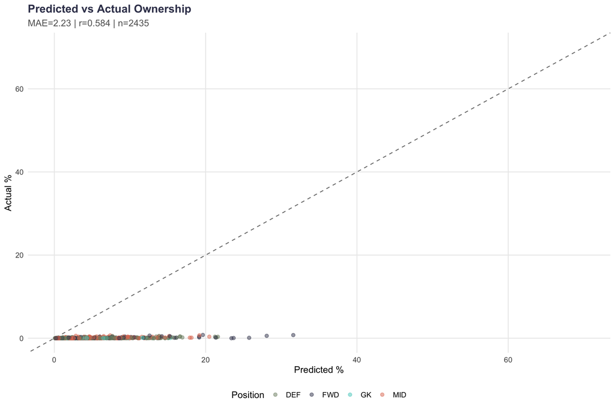

```r
# ============================================================
# SCATTER PLOTS
# ============================================================

final_weights <- c(mq = final$mq, form = final$form, value = final$value,
                   salary = final$salary, pb = final$pb)

final_preds <- predict_ownership(all_data, final_weights, best_k_vals, best_budget) %>%
  filter(!is.na(actual_own))

ggplot(final_preds, aes(x = pred_own, y = actual_own, color = pos)) +
  geom_abline(slope=1, intercept=0, linetype="dashed", color="grey50") +
  geom_point(alpha=0.5, size=2) +
  scale_color_manual(values = c(GK="#4ECDC4", DEF=sage, MID=coral, FWD=charcoal)) +
  labs(title = "Predicted vs Actual Ownership",
       subtitle = sprintf("MAE=%.2f | r=%.3f | n=%d", final$mae, final$cor, nrow(final_preds)),
       x = "Predicted %", y = "Actual %", color = "Position") +
  coord_cartesian(xlim = c(0,70), ylim = c(0,70))
```

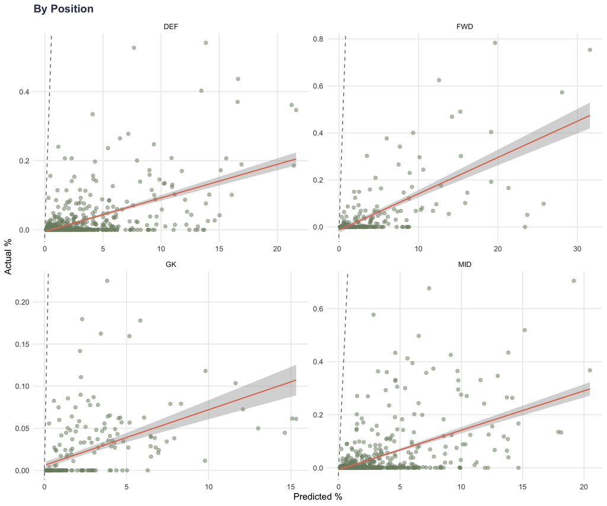

```r
ggplot(final_preds, aes(x = pred_own, y = actual_own)) +
  geom_abline(slope=1, intercept=0, linetype="dashed", color="grey50") +
  geom_point(alpha=0.5, size=2, color=sage) +
  geom_smooth(method="lm", se=TRUE, color=coral, linewidth=0.8) +
  facet_wrap(~pos, scales="free") +
  labs(title="By Position", x="Predicted %", y="Actual %")
```

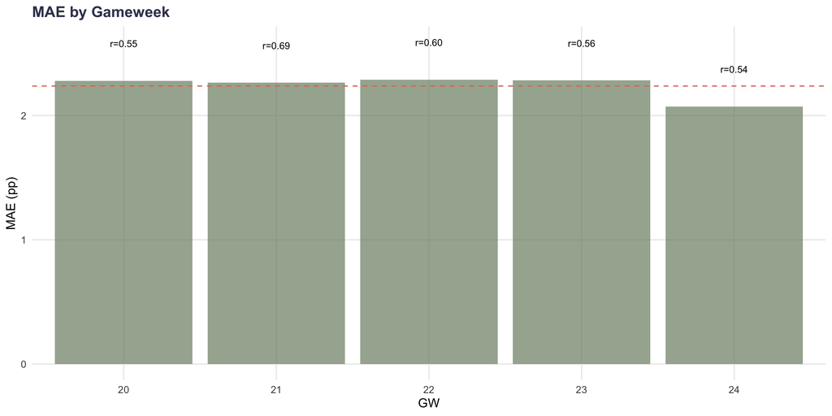

```r
gw_acc <- final_preds %>%
  group_by(gw) %>%
  summarise(mae = mean(abs(pred_own - actual_own), na.rm=TRUE),
            cor = tryCatch(cor(pred_own, actual_own, use="complete.obs"), error=function(e) NA_real_),
            n = n(), .groups="drop")

ggplot(gw_acc, aes(x=factor(gw))) +
  geom_col(aes(y=mae), fill=sage, alpha=0.7) +
  geom_text(aes(y=mae+0.3, label=sprintf("r=%.2f", coalesce(cor,0))), size=3.5) +
  labs(title="MAE by Gameweek", x="GW", y="MAE (pp)") +
  geom_hline(yintercept=mean(gw_acc$mae, na.rm=TRUE), linetype="dashed", color=coral)
```

```r
cat("\n\n## Worst Misses\n\n")
```

## Worst Misses

```r
worst <- final_preds %>%
  mutate(error = abs(pred_own - actual_own), dir = if_else(pred_own > actual_own, "Over", "Under")) %>%
  arrange(desc(error)) %>% head(20)

cat("<table><tr><th>GW</th><th>Player</th><th>Pos</th><th>Team</th><th>Pred</th><th>Actual</th><th>Error</th><th>Dir</th></tr>\n")
```

| GW | Player | Pos | Team | Pred | Actual | Error | Dir |
| --- | --- | --- | --- | --- | --- | --- | --- |
| 21 | Erling Haaland | FWD | Manchester City | 31.6 | 0.8 | 30.8 | Over |
| 22 | Hugo Ekitike | FWD | Liverpool | 28.1 | 0.6 | 27.5 | Over |
| 23 | Joao Pedro | FWD | Chelsea | 25.7 | 0.1 | 25.6 | Over |
| 22 | Joao Pedro | FWD | Chelsea | 23.7 | 0.1 | 23.6 | Over |
| 24 | Joao Pedro | FWD | Chelsea | 23.4 | 0.0 | 23.4 | Over |
| 20 | Gabriel Magalhaes | DEF | Arsenal | 21.6 | 0.3 | 21.3 | Over |
| 23 | Matheus Nunes | DEF | Manchester City | 21.4 | 0.2 | 21.2 | Over |
| 24 | Hugo Ekitike | FWD | Liverpool | 21.3 | 0.2 | 21.2 | Over |
| 24 | Gabriel Magalhaes | DEF | Arsenal | 21.2 | 0.4 | 20.9 | Over |
| 22 | Florian Wirtz | MID | Liverpool | 20.5 | 0.4 | 20.1 | Over |
| 20 | Georginio Rutter | FWD | Brighton | 19.1 | 0.2 | 19.0 | Over |
| 20 | Erling Haaland | FWD | Manchester City | 19.6 | 0.8 | 18.8 | Over |
| 21 | Igor Thiago | FWD | Brentford | 19.1 | 0.4 | 18.7 | Over |
| 23 | Antoine Semenyo | MID | Manchester City | 19.2 | 0.7 | 18.5 | Over |
| 21 | Bruno Guimaraes | MID | Newcastle United | 18.1 | 0.1 | 18.0 | Over |
| 20 | Declan Rice | MID | Arsenal | 17.9 | 0.1 | 17.8 | Over |
| 20 | Jan Paul van Hecke | DEF | Brighton | 16.9 | 0.2 | 16.7 | Over |
| 22 | Gabriel Magalhaes | DEF | Arsenal | 16.6 | 0.4 | 16.2 | Over |
| 21 | Keane Lewis-Potter | DEF | Brentford | 16.6 | 0.4 | 16.2 | Over |
| 21 | Nick Woltemade | FWD | Newcastle United | 16.1 | 0.1 | 16.0 | Over |

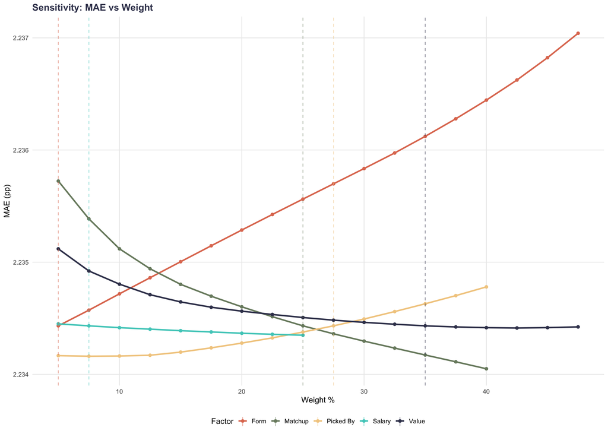

```r
# ============================================================
# SENSITIVITY ANALYSIS
# ============================================================

sensitivity_data <- list()
for (fn in c("mq","form","value","salary","pb")) {
  base <- final_weights
  for (tv in seq(0.05, 0.50, by = 0.025)) {
    rem <- 1.0 - tv
    others <- base[names(base) != fn]
    if (sum(others) > 0 && rem > 0) {
      scaled <- others * (rem / sum(others))
      if (all(scaled >= 0.04)) {
        tw <- c(scaled, tv); names(tw)[length(tw)] <- fn
        tw <- tw[c("mq","form","value","salary","pb")]
        tryCatch({
          s <- score_prediction(predict_ownership(all_data, tw, best_k_vals, best_budget))
          sensitivity_data[[length(sensitivity_data)+1]] <- data.frame(factor=fn, weight=tv, mae=s$mae, cor=s$cor)
        }, error = function(e) NULL)
      }
    }
  }
}

sens_df <- bind_rows(sensitivity_data)
fl <- c(mq="Matchup", form="Form", value="Value", salary="Salary", pb="Picked By")

ggplot(sens_df, aes(x=weight*100, y=mae, color=factor)) +
  geom_line(linewidth=1.2) + geom_point(size=2) +
  scale_color_manual(values=c(mq=sage, form=coral, value=charcoal, salary="#4ECDC4", pb="#F2CC8F"), labels=fl) +
  geom_vline(data=data.frame(factor=names(final_weights), opt=as.numeric(final_weights)*100),
             aes(xintercept=opt, color=factor), linetype="dashed", alpha=0.5) +
  labs(title="Sensitivity: MAE vs Weight", x="Weight %", y="MAE (pp)", color="Factor")
```

```r
cat("\n\n## Factor Importance\n\n")
```

## Factor Importance

```r
fi <- sens_df %>% group_by(factor) %>%
  summarise(mae_range = max(mae)-min(mae), best_wt = weight[which.min(mae)]*100, best_mae = min(mae), .groups="drop") %>%
  arrange(desc(mae_range)) %>% mutate(label = fl[factor])

cat("<table><tr><th>#</th><th>Factor</th><th>Best Wt</th><th>MAE Range</th></tr>\n")
```

| # | Factor | Best Wt | MAE Range |
| --- | --- | --- | --- |
| 1 | Form | 5% | 0.003 |
| 2 | Matchup | 40% | 0.002 |
| 3 | Value | 42% | 0.001 |
| 4 | Picked By | 8% | 0.001 |
| 5 | Salary | 25% | 0.000 |

```r
cat("\n\n## Ready-to-Use Code\n\n")
```

## Ready-to-Use Code

````r
cat("```r\n")
````

````r
``` r
cat("# ---- Optimized weights (", format(Sys.Date(), "%Y-%m-%d"), ") ----\n")
````

# —- Optimized weights ( 2026-02-04 ) —-

```r
cat(sprintf("w_mq     <- %.3f\n", final$mq))
```

w_mq <- 0.250

```r
cat(sprintf("w_form   <- %.3f\n", final$form))
```

w_form <- 0.050

```r
cat(sprintf("w_value  <- %.3f\n", final$value))
```

w_value <- 0.350

```r
cat(sprintf("w_salary <- %.3f\n", final$salary))
```

w_salary <- 0.075

```r
cat(sprintf("w_pb     <- %.3f\n", final$pb))
```

w_pb <- 0.275

```r
cat(sprintf("\npos_budgets <- c(GK = %d, DEF = %d, MID = %d, FWD = %d)\n",
            best_budget["GK"], best_budget["DEF"], best_budget["MID"], best_budget["FWD"]))
```

pos_budgets <- c(GK = 100, DEF = 400, MID = 400, FWD = 200)

```r
cat(sprintf("pos_k <- c(GK = %d, DEF = %d, MID = %d, FWD = %d)\n",
            best_k_vals["GK"], best_k_vals["DEF"], best_k_vals["MID"], best_k_vals["FWD"]))
```

pos_k <- c(GK = 6, DEF = 6, MID = 6, FWD = 6)

````r
cat("```\n\n")
````

````
``` r
cat(sprintf("<div class='interp-box'>MAE = %.2f, Cor = %.3f, %d matched across %d GWs.</div>\n",
            final$mae, final$cor, final$n, n_distinct(all_data$gw)))
````

MAE = 2.23, Cor = 0.584, 2435 matched across 5 GWs.

```r
cat(sprintf("\n\n---\nGenerated %s | Optimizer v3.0\n", format(Sys.time(), "%d %b %Y %H:%M")))
```

```
##
##
## ---
## Generated 04 Feb 2026 21:07 | Optimizer v3.0
```